# Linear and Quadratic Discriminant Analysis

Benjamin Draves

## Introduction & Background

We implement Quadratic Discriminant Analysis (QDA) and Linear Discriminant Analysis (LDA) for classifying 11 vowels based on $p = 10$ features $\{X_i\}_{i=1}^p$. We compare the classifications from QDA based on the $p-$dimensional space $\mathcal{X} = \{X_i: 1\leq i \leq p \}$ and compare these classifications to LDA an expanded, $(2p + \binom{p}{2})-$dimensional feature space $\tilde{\mathcal{X}} = \{X_i, X_i^2, X_iX_j: 1\leq, i,j\leq p \}$. We begin by implementing methods that calculate the quadratic discriminant functions $\tilde{\delta}_k(\cdot)$ and linear discriminant functions $\delta_k(\cdot)$
$$\begin{align*}
\tilde{\delta}_k(x) &= -\frac{1}{2}\log|\Sigma_k| - \frac{1}{2}(x-\mu_k)^T\Sigma_k^{-1}(x-\mu_k) + \log\pi_k\\
\delta_k(x) &= x^T\Sigma^{-1}\mu_k - \frac{1}{2}\mu_k^T\Sigma^{-1}\mu_k + \log\pi_k
\end{align*}$$
As stated in equation 4.10 (ESL pg. 109), classifying based on LDA is equivalent to the decision rule $G(x) = \arg\max_k\delta_k(x)$. To see why this decision rule also holds for QDA, consider the QDA log-ratio,
$$\begin{align*}
\log\frac{\mathbb{P}(G = k|X =x)}{\mathbb{P}(G = \ell|X =x)}&= \log\frac{f_k(x)}{f_{\ell}(x)} + \log\frac{\pi_k}{\pi_{\ell}}\\
&= \log\frac{(2\pi)^{-p/2}\text{det}(\Sigma_k)^{-1/2}\exp\left\{-\frac{1}{2}(x-\mu_k)^T\Sigma_k^{-1}(x-\mu_k)\right\}}{(2\pi)^{-p/2}\text{det}(\Sigma_{\ell})^{-1/2}\exp\left\{-\frac{1}{2}(x-\mu_{\ell})^T\Sigma_{\ell}^{-1}(x-\mu_{\ell})\right\}} + \log\frac{\pi_k}{\pi_{\ell}}\\
&= \log\frac{\text{det}(\Sigma_k)^{-1/2}}{\text{det}(\Sigma_{\ell})^{-1/2}} + \log\frac{\exp\left\{-\frac{1}{2}(x-\mu_k)^T\Sigma_k^{-1}(x-\mu_k)\right\}}{\exp\left\{-\frac{1}{2}(x-\mu_{\ell})^T\Sigma_{\ell}^{-1}(x-\mu_{\ell})\right\}} + \log\frac{\pi_k}{\pi_{\ell}}\\
&= -\frac{1}{2}\log\text{det}(\Sigma_k) -\frac{1}{2}(x-\mu_k)^T\Sigma_k^{-1}(x-\mu_k) + \log\pi_k\\
&+\frac{1}{2}\log\text{det}(\Sigma_{\ell}) +\frac{1}{2}(x-\mu_{\ell})^T\Sigma_{\ell}^{-1}(x-\mu_{\ell}) - \log\pi_k\\
&= \tilde{\delta}_k(x) - \tilde{\delta}_{\ell}(x)
\end{align*}$$
Therefore, if we fix $\ell$, we would classify based on the rule
$$\begin{align*}
G(x) = \begin{cases}
\arg\max_k\tilde{\delta}_k(x) & \exists k\neq \ell: \tilde{\delta}_{k}(x)\geq\tilde{\delta}_{\ell}(x) \\
\ell & \not\exists k\neq \ell: \tilde{\delta}_{k}(x)\geq\tilde{\delta}_{\ell}(x) \\
\end{cases}
\end{align*}$$
Notice, however that $\not\exists k\neq \ell: \tilde{\delta}_{k}(x)\geq\tilde{\delta}_{\ell}(x)$ is an equivalent condition to $\tilde{\delta}_{\ell}(x)\geq\tilde{\delta}_{k}(x)$ for all $k$. Moreover, the first condition requires we classify to the class corresponding to the largest $\tilde{\delta}_k(x)$ where $\tilde{\delta}_{k}(x)\geq\tilde{\delta}_{\ell}(x)$. Therefore, in either case, we see we classify to the class corresponding to the largest discriminant function. Thus we see we can rewrite both classification rules as follows
$$\begin{align*}
\hat{G}_{LDA} = \arg\max_k\delta_k(x)\quad\quad \hat{G}_{QDA} = \arg\max_k\tilde{\delta}_k(x)
\end{align*}$$

Therefore our implementation will be focused on the efficient calculation of the discriminate functions $(\delta_k, \tilde{\delta}_k)_{k=1}^K$ based on the training data. From here, we will evaluate these functions with the test data to produce predictions. We beging with implementing QDA followed by LDA.

## Implementation of Quadratic Discriminant Analysis (QDA)

```r
#read in data
train <- read.csv("~/Documents/Work/github/Courses/MA 751/DA1/Data/vowel.train.txt")
test <- read.csv("~/Documents/Work/github/Courses/MA 751/DA1/Data/vowel.test.txt")

#clean data
train <- as.matrix(train[,-1])
test <- as.matrix(test[,-1])

#----------------------------------
#
#         QDA Implemenation
#
#----------------------------------

#function: est - return mean/covariance estimates
#arguments:
#       X - data matrix corresponding to class k
est <- function(X){
  mu <- colMeans(X)
  Sigma <- cov(scale(X, scale = FALSE))
  return(list(mu = mu, Sigma = Sigma))
}

#function: deltaQDA - return quadratic discriminant function
#arguments:
#       x - test point
#       mu - estimated group mean
#       Sigma - estimated group covariance
#       lp - estimated log - prior prob
deltaQDA <- function(x, mu, Sigma, lp){

    #numerically stable matrix inversion
    C <- chol(Sigma)
    y <- backsolve(C, matrix(x - mu, ncol = 1), trans = TRUE)
    b <- backsolve(C,y)

    #return discriminant function
    -.5 * log(det(Sigma)) - .5 * crossprod(x - mu, b) + lp
}

#function: QDA - return classification
#arguments:
#       x - test point
QDA <-local({

  #local variable declarations to avoid redundant calculations
  #calculate log prior class probability
  lpi <- log(as.numeric(prop.table(table(train[,1]))))

  #calculate class means & covariances
  K <- length(unique(train[,1]))
  mus <- list(K)
  Sigmas <- list(K)

  for(k in 1:K){
    #subset dataframe to get class k & get estimates
    df <- train[,-1][which(train[,1] == k), ]
    tmp <- est(df)

    #store estimates
    mus[[k]] <- tmp$mu
    Sigmas[[k]] <- tmp$Sigma

  }
  #return maximum discriminant function
  function(x) which.max(sapply(1:K, function(y) deltaQDA(x, mus[[y]], Sigmas[[y]], lpi[y])))

})
```

## Implementation of Linear Discriminant Analysis (LDA)

```r
#----------------------------------
#
#         LDA Implemenation
#
#----------------------------------
#Set up new training/testing data in X~
train.new <- matrix(NA, nrow = nrow(train) , ncol  = 1 + 10 + 10 + choose(10, 2))
train.new[,1:11] <- as.matrix(train)

test.new <- matrix(NA, nrow = nrow(test) , ncol  = 10 + 10 + choose(10, 2))
test.new[,1:10] <- as.matrix(test[,-1])

#Expand covariate space to incldue (Xi*Xj, Xi^2)
count <- 1
for(i in 1:10){
  for(j in i:10){
    train.new[,11 + count] <- train[,i + 1] * train[,j + 1]
    test.new[,10 + count] <- test[,i + 1] * test[,j + 1]
    count <- count + 1
  }
}

#function: deltaLDA - return linear discriminant function
#arguments:
#       x - test point
#       mu - estimated group mean
#       lp - estimate log prior probs

deltaLDA <- local({
    #calculate common Sigma with bias correction
    N <- nrow(train.new); K <- length(unique(train[,1]))
    Sigmas <- list(K)

    #calculate group covariances
    for(k in 1:K){
      df <- train.new[,-1][which(train.new[,1] == k), ]
      Sigmas[[k]] <- (N-1)*cov(scale(df, scale = FALSE))
    }
    #calculate full covariance
    Sigma <- 1/(N - K) * Reduce("+", Sigmas)


    function(x, mu, lp){
      #numerically stable matrix inversion
      C <- chol(Sigma)
      y <- backsolve(C, matrix(mu, ncol = 1), trans = TRUE)
      b <- backsolve(C,y)

      #return discriminant function
      crossprod(x, b) - .5 * crossprod(mu, b) + lp
    }
})

#function: LDA - return classification
#arguments:
#       x - test point
LDA <-local({
  #define local varibles to avoide redundants caculations
  #calculate prior class probabilities
  lpi <- log(as.numeric(prop.table(table(train.new[,1]))))

  #calculate class means
  K <- length(unique(train.new[,1]))
  mus <- list(K)
  for(k in 1:K){
    #subset dataframe & get estimates
    df <- train.new[,-1][which(train.new[,1] == k), ]

    #store estimates
    mus[[k]] <- colMeans(df)
  }
  #return classifications
  function(x) which.max(sapply(1:K, function(y) deltaLDA(x, mus[[y]], lpi[y])))

})
```

## Application to Test Set

```r
#format test data
test.X <- as.matrix(test[,-1]); colnames(test.X) = rep("", ncol(test.X))

#get predictions
yhat <- apply(test.X, 1, QDA)

#get get misclassification rate
MR <- sum(yhat != test[,1])/nrow(test)
MR
```

```
## [1] 0.5281385
```

```r
#make figure
library(ggplot2); library(gridExtra)

df1 <- data.frame(X1 = test.X[,1], X2 = test.X[,2], class = as.factor(yhat))
df2 <- data.frame(X1 = test.X[,1], X2 = test.X[,2], class = as.factor(test[,1]))

p1 <- ggplot(df1, aes(X1, X2, col = class))+
  geom_point(alpha = .25)+
  labs(title = "QDA")+
  theme(legend.position="none",
        panel.background = element_rect(fill = 'white', colour = 'black'))

p2 <- ggplot(df2, aes(X1, X2, col = class))+
  labs(title = "Test")+
  geom_point(alpha = .25)+
  theme(legend.position="none",
        panel.background = element_rect(fill = 'white', colour = 'black'))
```

```r
#get predictions
yhat.new <- apply(test.new, 1, LDA)

#get get misclassification rateth4
MR.new <- sum(yhat.new != test[,1])/nrow(test)
MR.new
```

```
## [1] 0.4393939
```

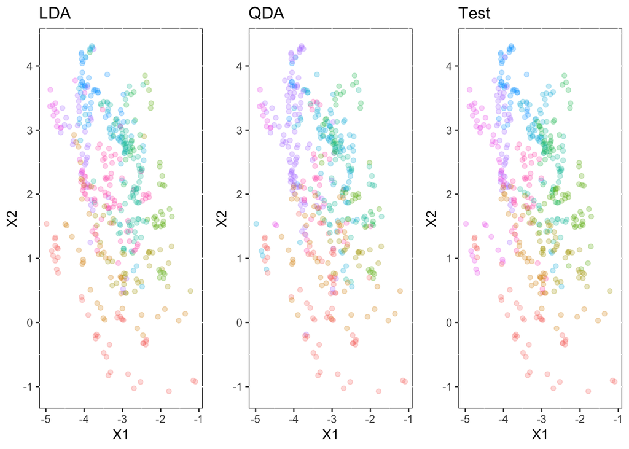

```r
#make figure
df3 <- data.frame(X1 = test.new[,1], X2 = test.new[,2], class = as.factor(yhat.new))

p3 <- ggplot(df3, aes(X1, X2, col = class))+
  geom_point(alpha = .25)+
  labs(title = "LDA")+
  theme(legend.position="none",
        panel.background = element_rect(fill = 'white', colour = 'black'))

grid.arrange(p3, p1, p2, ncol=3)
```